# Data Analytics Portfolio

### 4.2.2 Aesthetic Mappings

1. What’s gone wrong with this code? Why are the points not blue?

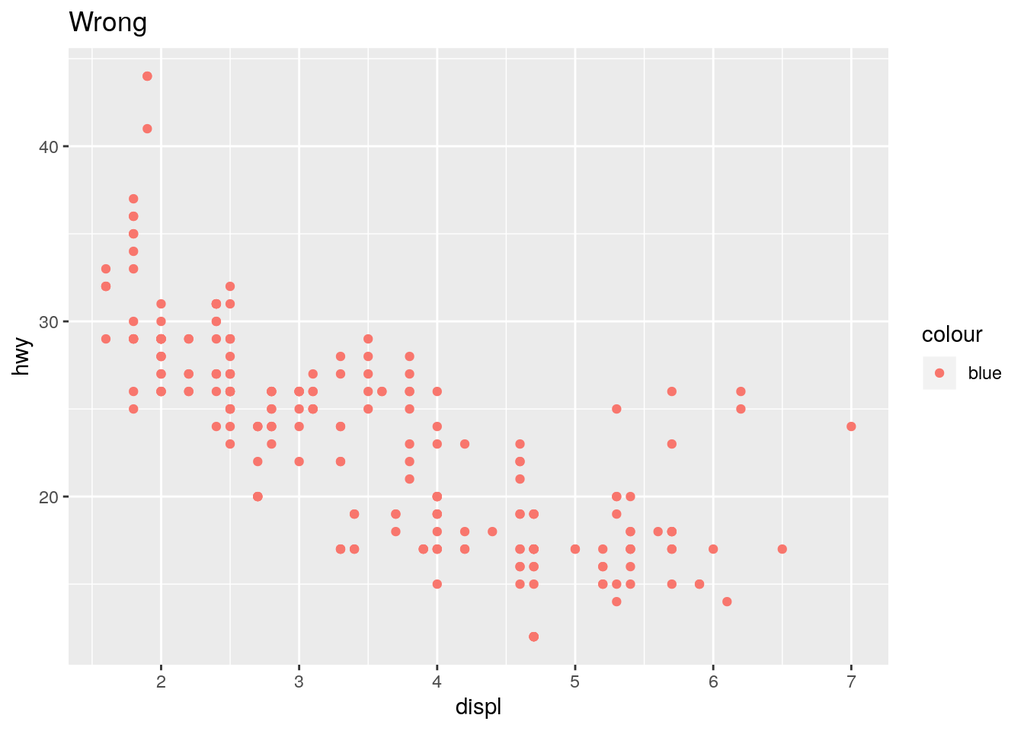

```r
ggplot(data = mpg) +
  geom_point(mapping = aes(x = displ, y = hwy, color = "blue")) +
  labs(title="Wrong")
```

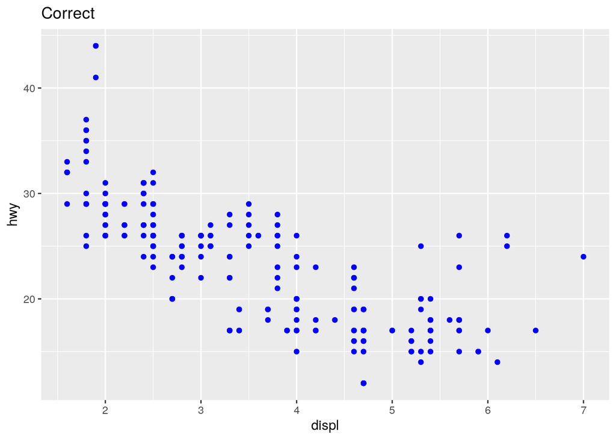

```r
ggplot(data = mpg) +
  geom_point(mapping = aes(x = displ, y = hwy), color = "blue") +
  labs(title="Correct")
```

The color aesthetic was in the aes() so it was treated as a variable.

2. Which variables in mpg are categorical? Which variables are continuous? (Hint: type ?mpg to read the documentation for the dataset). How can you see this information when you run mpg?

```r
?mpg
str(mpg)
```

```
## Classes 'tbl_df', 'tbl' and 'data.frame':    234 obs. of  11 variables:
##  $ manufacturer: chr  "audi" "audi" "audi" "audi" ...
##  $ model       : chr  "a4" "a4" "a4" "a4" ...
##  $ displ       : num  1.8 1.8 2 2 2.8 2.8 3.1 1.8 1.8 2 ...
##  $ year        : int  1999 1999 2008 2008 1999 1999 2008 1999 1999 2008 ...
##  $ cyl         : int  4 4 4 4 6 6 6 4 4 4 ...
##  $ trans       : chr  "auto(l5)" "manual(m5)" "manual(m6)" "auto(av)" ...
##  $ drv         : chr  "f" "f" "f" "f" ...
##  $ cty         : int  18 21 20 21 16 18 18 18 16 20 ...
##  $ hwy         : int  29 29 31 30 26 26 27 26 25 28 ...
##  $ fl          : chr  "p" "p" "p" "p" ...
##  $ class       : chr  "compact" "compact" "compact" "compact" ...
```

| Categorical | Continious |
| --- | --- |
| manufacturer | cty |
| model | hwy |
| trans | year |
| drv | cyl |
| fl |  |
| class |  |

3. Map a continuous variable to color, size, and shape. How do these aesthetics behave differently for categorical vs. continuous variables?

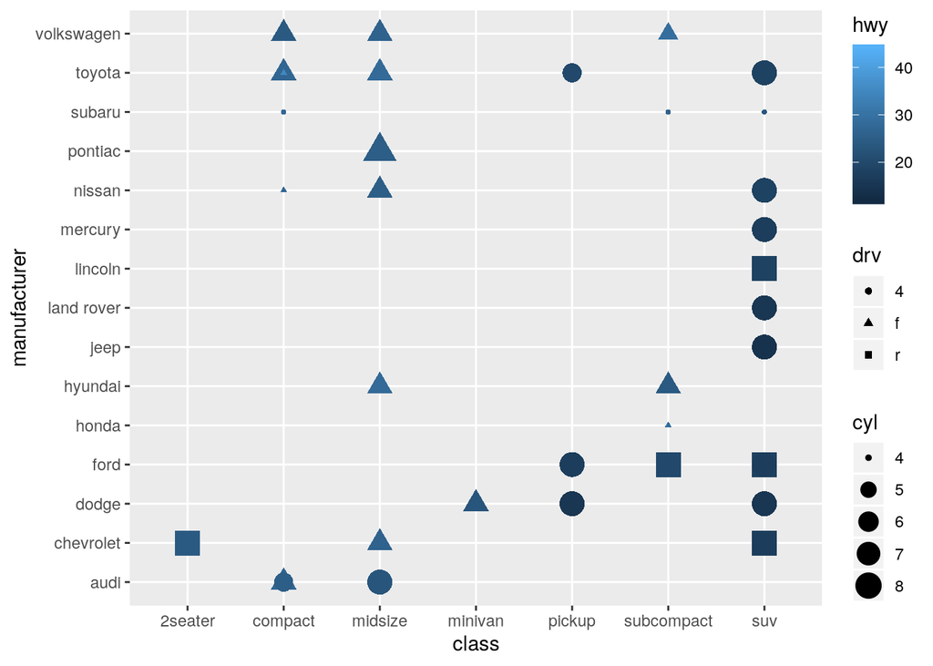

```r
ggplot(data = mpg) +
  geom_point(aes(x = class, y = manufacturer,size = cyl,shape = drv, color = hwy))
```

4. What happens if you map the same variable to multiple aesthetics?

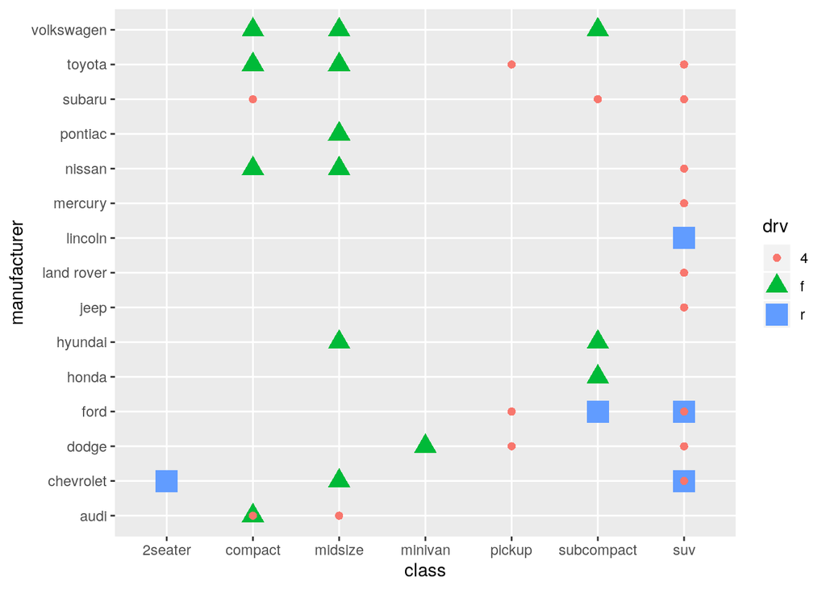

```r
ggplot(data = mpg) +
  geom_point(aes(x = class, y = manufacturer,size = drv,shape = drv, color = drv))
```

When mapping a single variable to multiple aesthetics, R merges them into one image and puts it in one legend.

5. What does the stroke aesthetic do? What shapes does it work with? (Hint: use ?geom_point)

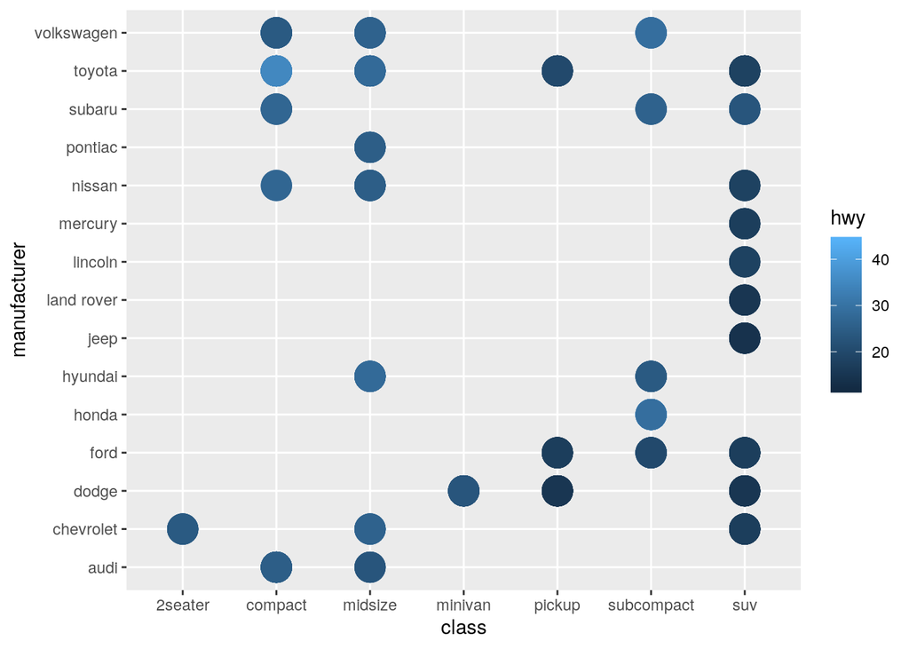

```r
?geom_point

ggplot(data = mpg) +
  geom_point(aes(x = class, y = manufacturer,stroke = 5, color=hwy))
```

6. What happens if you map an aesthetic to something other than a variable name, like aes(colour = displ < 5)? Note, you’ll also need to specify x and y.

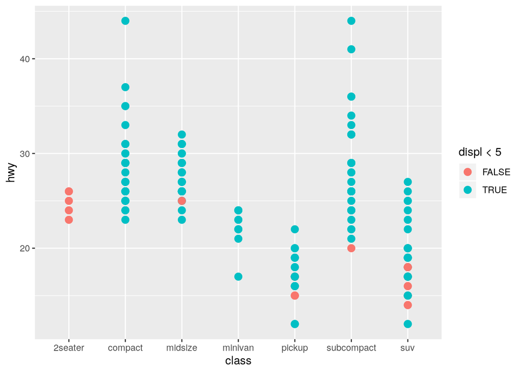

```r
ggplot(mpg) +
  geom_point(aes(x = class, y= hwy,colour = displ < 5),size=3)
```

### 4.2.3 Facets

Created by Michael Molloy

*molloytech@gmail.com |* |